# SMO

Practical Assignment: Support Vector Machines

Métodos Avanzados en Aprendizaje Automático

Carlos María Alaíz Gudín - Universidad Autónoma de Madrid

**Initial Configuration**

This cell defines the configuration of Jupyter Notebooks.

```python
%%html
<head><link rel="stylesheet" href="style.css"></head>
```

```python
%matplotlib inline
%load_ext autoreload
%autoreload 2
```

This cell imports the packages to be used (all of them quite standard except for `Utils`, which is provided with the notebook).

```python
import numpy as np

import matplotlib
import matplotlib.pyplot as plt
from IPython.display import HTML
from Utils import plot_dataset_clas, plot_svc

matplotlib.rc('figure', figsize=(15, 5))

seed = 123
```

# Introduction

This practical assignment consists in implementing a simplified version of the SVC class of `sklearn`.

This class will contain two fundamentals routines, one for training a non-linear SVC (using the RBF kernel), based on the SMO algorithm for solving the dual optimization problem, and the other one for predicting over new out-of-sample points.

# SMO Algorithm

## Optimization Problem

The dual optimization problem for the Soft-Margin SVM is: $$ \left \{ \begin{array}{l} \min_{\boldsymbol{\alpha} \in \mathbb{R}^N} \frac{1}{2} \boldsymbol{\alpha}^\intercal \tilde{\mathbf{K}} \boldsymbol{\alpha} - \boldsymbol{\alpha}^\intercal \mathbf{1} \\ \text{ s.t. } \boldsymbol{\alpha}^\intercal \mathbf{y} = 0 , 0 \le \boldsymbol{\alpha} \le C , \end{array} \right . $$ where $\tilde{k}_{ij} = y_i y_j \mathcal{K}(\mathbf{x}_i, \mathbf{x}_j)$.

This optimization problem is a QP problem, which is usually solved using an *ad hoc* algorithm: Sequential Minimal Optimization (SMO).

## SMO and Coordinate Descent

The main idea behind SMO is that the optimization problem is too involved to be solved as a whole, but it can be largely simplified considering only a few variables at a time. In this divide-and-conquer approach, called coordinate descent, the objective function is iteratively minimized over the different variables.

In particular, SMO deals with two variables, the smaller working group that can be modified while respecting the constraints. Formally, the algorithm updates the current $\alpha^\text{old}_i$ and $\alpha^\text{old}_j$ coefficients to some new values $\alpha_i$ and $\alpha_j$, assuming that $\boldsymbol{\alpha}^\text{old}$ satisfies $(\boldsymbol{\alpha}^\text{old})^\intercal \mathbf{y} = 0$. In order to keep respecting the constraint in the new estimation, the following equation needs to be fulfilled: \begin{align*} & y_i \alpha^\text{old}_i + y_j \alpha^\text{old}_j = y_i \alpha_i + y_j \alpha_j \\ &\implies y_i (\alpha_i - \alpha^\text{old}_i) = - y_j (\alpha_j - \alpha^\text{old}_j) \\ &\implies \alpha_i = \alpha^\text{old}_i - y_i y_j (\alpha_j - \alpha^\text{old}_j) . \end{align*}

For simplicity, one can assume that the update for the $j$-th coefficient is given by $\alpha_j = \alpha^\text{old}_j + d$, and hence the optimization problem becomes a simple one-dimensional minimization. Therefore, it can be solved by computing the derivative with respect to $d$ and equating to $0$. After some derivations, the optimum unconstrained update turns out to be: \begin{align*} d &= \frac{y_j (E(\mathbf{x}_j, y_j) - E(\mathbf{x}_i, y_i))}{\kappa} , \text{ where} \\ \kappa &= 2 \mathcal{K}(\mathbf{x}_i, \mathbf{x}_j) - \mathcal{K}(\mathbf{x}_i, \mathbf{x}_i) - \mathcal{K}(\mathbf{x}_j, \mathbf{x}_j) , \text{ and} \\ E(\mathbf{x}, y) &= \sum_{i = 1}^N \alpha^\text{old}_i y_i \mathcal{K}(\mathbf{x}_i, \mathbf{x}) - y . \end{align*}

## Clipping

The previous update does not take into account the box constrains $0 \le \alpha_i, \alpha_j \le C$. In order to satisfy these constraints for both $\alpha_i$ and $\alpha_j$, $\alpha_j$ has to be clipped to the interval $[L, H]$, where $$ \begin{cases} L = \max(0, \alpha^\text{old}_j - \alpha^\text{old}_i), & H = \min(C, C - \alpha^\text{old}_i + \alpha^\text{old}_j) & \text{if } y_i \neq y_j , \\ L = \max(0, \alpha^\text{old}_j + \alpha^\text{old}_i - C), & H = \min(C, \alpha^\text{old}_i + \alpha^\text{old}_j) & \text{if } y_i = y_j . \end{cases} $$

Therefore, the update for $\alpha_j$ becomes: $$ \alpha_j = \min(\max(\alpha^\text{old}_j + d, L), H) , $$ and, as mentioned above, the corresponding update for $\alpha_i$ is: $$ \alpha_i = \alpha^\text{old}_i - y_i y_j (\alpha_j - \alpha^\text{old}_j) . $$

## Selecting the Working Pair

There are different methods for selecting the working pair of coefficients $(i, j)$ that will be updated. Usually, first or second order information is used to choose the working set, trying to find those that will provide the largest minimization of the objective function.

Nevertheless, in this work a simplified version of SMO will be implemented. The first coefficient $i$ will be selected just iteratively, cycling over all the possible values $i = 1, 2, \dotsc, N$. The second coefficient $j$ is selected randomly over the remaining possible values $j \neq i$.

It should be noted that this approach will not guarantee the convergence in general, since not all possible pairs $(i, j)$ are explored, but it will work in most problems.

## Stopping Criteria

The algorithm will be terminated when a certain maximum number of iteration is reached (for each iteration, all the coefficients are updated), or when after one iteration the total change of the coefficients is smaller than a certain tolerance, $\| \boldsymbol{\alpha} - \boldsymbol{\alpha}^\text{old}\| < \epsilon$.

Since the working pair is generated randomly, it can happen that after a whole iteration the changes are smaller than $\epsilon$ not because the optimization is finished, but because of "bad luck". A workaround is to set $\epsilon = 0$ to force all the iterations.

## Computing the Intercept

Once the optimum dual coefficients $\boldsymbol{\alpha}^*$ have been estimated, the intercept $b^*$ can be computed knowing that any support vector $\mathbf{x}_k$ with $0 < \alpha^*_k < C$ satisfies: $$ b^* = y_k - \sum_{i = 1}^N \alpha^*_i y_i \mathcal{K}(\mathbf{x}_i, \mathbf{x}_k) . $$

This equality is usually averaged over all the possible vectors $k$ satisfying $0 < \alpha^*_k < C$ for reasons of numerical stability.

## Prediction

Once the model is trained and the optimal parameters $\boldsymbol{\alpha}^*$ and $b^*$ are known, the score predicted over a new sample $\mathbf{x}$ is: $$ f(\mathbf{x}) = \sum_{i = 1}^N \alpha^*_i y_i \mathcal{K}(\mathbf{x}_i, \mathbf{x}) + b . $$

Finally, the class is assigned with: $$ \hat{y} = \operatorname{sign}(f(\mathbf{x})) . $$

# Implementation of the SVC

## Requirements

The objective of this assignment is to complete the class `MySVC` sketched below, which should contain at least the following methods.

```
__init__(self, C=1.0, gamma="scale", tol=0.0001, max_iter=10000)
```

- This is the construction method for the class, with the following parameters:
  - `C`: Regularization parameter $C$ of the SVC.
  - `gamma`: Kernel parameter $\gamma$ of the RBF kernel.
  - `tol`: Tolerance for the stopping criterion $\epsilon$.
  - `max_iter`: Maximum number of iterations (in the sense of epochs, each iteration contains a pass through all the coefficients).
- This method should only store the parameters in fields of the class, to be used when needed.

```
fit(self, X, y)
```

- This is the training method, with the following parameters:
  - `X`: Training data matrix $\mathbf{X} \in \mathbb{R}^{N \times d}$.
  - `y`: Vector of labels $\mathbf{y}$, with $y_i \in \{-1, +1\}$.
- This method should solve the dual optimization problem, storing the obtained coefficients and other useful information in fields of the class.

```
decision_function(self, X)
```

- This is the method that computes the output of the SVC, with the following parameters:
  - `X`: Test data matrix $\mathbf{X}' \in \mathbb{R}^{N' \times d}$.
- This method should predict the output (the score) of the SVC, using the information stored in the fields of the class, and return it as a vector

```
predict(self, X)
```

- This is the method that computes the predicted class of the SVC, with the following parameters:
  - `X`: Test data matrix $\mathbf{X}' \in \mathbb{R}^{N' \times d}$.
- This method should predict the assigned class of the SVC, using the information stored in the fields of the class, and return it as a vector.

## Recommendations

Additional auxiliary methods can be defined to simplify the code. Some suggestions are:

1. A method to compute the output of the SVC, with the current estimated parameters but without considering the intercept: $$ \sum_{i = 1}^N \alpha_i y_i \mathcal{K}(\mathbf{x}_i, \mathbf{x}) . $$
2. A method to compute $E(\mathbf{x}, y)$.
3. A method to compute the lower and upper bounds $L$ and $H$ for the clipping of the update.
4. A method to estimate $b^*$.

## Implementation

* Complete the `MySVC` class below, satisfying the described requirements.

```python
import numpy as np
from sklearn.metrics.pairwise import rbf_kernel

class MySVC():
    """
        SVC with a simplified version of SMO.
    """
    def __init__(self, C=1.0, gamma="scale", tol=0.0001, max_iter=10000):
        """
        Assignment of the hyper-parameters.
        """
        self.C = C
        self.gamma = gamma
        self.tol = tol
        self.max_iter = max_iter
        self.kernel = 'rbf'

    def fit(self, X, y):
        """
            Fit SVC with SMO algorithm.
        """
        # Constants.
        n_pat = X.shape[0]
        n_dim = X.shape[1]

        # Options for gamma (for compatibility with sklean).
        if (self.gamma == "scale"):
            self.gamma = 1.0 / (n_dim * X.var())
        if (self.gamma == "auto"):
            self.gamma = 1.0 / n_dim

        # Initialization of the dual coefficients (named "a" instead of "alpha" for simplicity).
        self.a = np.zeros(n_pat)

        # Other initializations (complete).
        self.X = X
        self.y = y

        # Loop over the iterations.
        for it in range(self.max_iter):
            # Initializations.
            a_old = np.array(self.a, copy=True)


            # Loop over the coefficients.
            for i in range(0, n_pat):
                j = self.choose_j(i)
                ajold = self.a[j]

                # Update of the corresponding a[i] and a[j] values.
                d = y[j] * (self.E(j) - self.E(i)) / self.kappa(i, j)
                L, H = self.clipping(i, j, condition = (y[i] == y[j]))
                self.a[j] = min(max(ajold + d, L), H)
                self.a[i] += - y[i] * y[j] * (self.a[j] - ajold)


            # Check of the stopping conditions.
            if np.linalg.norm(self.a - a_old) < self.tol:
                break

        # Storage of the obtained parameters and computation of the intercept.
        self.sv_cond_ = np.where((self.a > 0) & (self.a < self.C))[0]
        self.support_vectors_ = self.X[self.sv_cond_]
        self.b_ = self.intercept(self.sv_cond_)
        self.dual_coef_ = self.y[self.sv_cond_] * self.a[self.sv_cond_] # same from sklearn

        return self

    def decision_function(self, X):
        """
            Computation of the decision function over X
        """
        return self.output(X) + self.b_

    def predict(self, X):
        """
            Computation of the predicted class over X.
        """
        return np.sign(self.decision_function(X))

    def clipping(self, i, j, condition=False):
        """
            Computation clipping (lower & upper bounds)
        """
        update1 = max(0, self.a[j] + self.a[i] - self.C), min(self.C, self.a[i] + self.a[j])
        update2 = max(0, self.a[j] - self.a[i]), min(self.C, self.C - self.a[i] + self.a[j])
        return update1 if condition else update2

    def kappa(self, i, j):
        """
            Kappa for intercept
        """
        return (2*rbf_kernel(self.X[i][None], self.X[j][None], self.gamma)[0,0] -
                rbf_kernel(self.X[i][None], self.X[i][None], self.gamma)[0,0] -
                rbf_kernel(self.X[j][None], self.X[j][None], self.gamma)[0,0])

    def output(self, X):
        """
            Output function
        """
        return (self.a * self.y) @ rbf_kernel(self.X, X, self.gamma)

    def E(self, i):
        """
            Computation expected value
        """
        return self.output(self.X[i][None])[0] - self.y[i]

    def intercept(self, k):
        """
            Computation of the intercept
        """
        return np.mean(self.y[k] - self.output(self.X[k]))


    def choose_j(self, i):
        v = np.arange(len(self.a))
        return np.random.choice(v[v != i])
```

# Experiments with the SVC

## Comparative with *scikit-learn*

The following cell generates the *moons* dataset, dividing it into train and test splits, and depicting it.

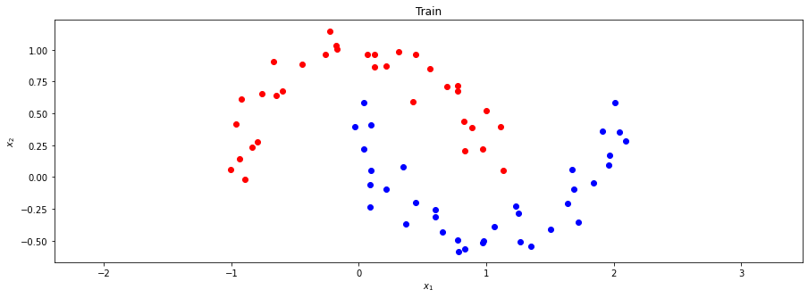

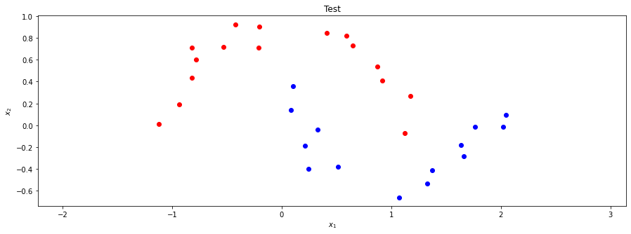

```python
from sklearn.datasets import make_moons
from sklearn.model_selection import train_test_split
from sklearn.svm import SVC

x, y = make_moons(noise=1e-1, random_state=seed)
y[y != 1] = -1

x_tr, x_te, y_tr, y_te = train_test_split(x, y, test_size=0.3, random_state=seed)

plot_dataset_clas(x_tr, y_tr)
plt.title('Train'); plt.show()
plot_dataset_clas(x_te, y_te)
plt.title('Test'); plt.show()
```

* Train an SVC model over the training data (`x_tr`, `y_tr`), using both the `SVC` class of `sklearn` and the implemented `MySVC` class. * Predict using the previous two models over the test data (`x_te`, `y_te`). * Compare that both classes provide the same outputs (in terms of the decision function and of the predicted class), describing the obtained results. If needed, reduce the default stopping tolerance and/or increase the default maximum number of iterations.

```python
import time

C = 1
gamma = 'scale'

model_my = MySVC(C=C, gamma=gamma)
model_sk = SVC(C=C, gamma=gamma)


# Training of the models.
t1_start = time.process_time()
model_my.fit(x_tr,y_tr)
t1_end = time.process_time()
print("Training time for our SVC model: {0:.4f} ms".format((t1_end - t1_start)*1000))

t2_start = time.process_time()
model_sk.fit(x_tr,y_tr)
t2_end = time.process_time()
print("Training time for sklearn SVC model: {0:.4f} ms".format((t2_end - t2_start)*1000))

# Comparative of the predicted scores.
scores_my = model_my.decision_function(x_te)
scores_sk = model_sk.decision_function(x_te)

# Comparative of the predicted classes.
predictions_my = model_my.predict(x_te)
predictions_sk = model_sk.predict(x_te)
```

```
Training time for our SVC model: 2225.3642 ms
Training time for sklearn SVC model: 1.1527 ms
```

En términos computacionales, se observa que el modelo SVC de SKLearn es aproximadamente 1930.56 veces más eficiente que nuestra implementación.

### Vectores de soporte

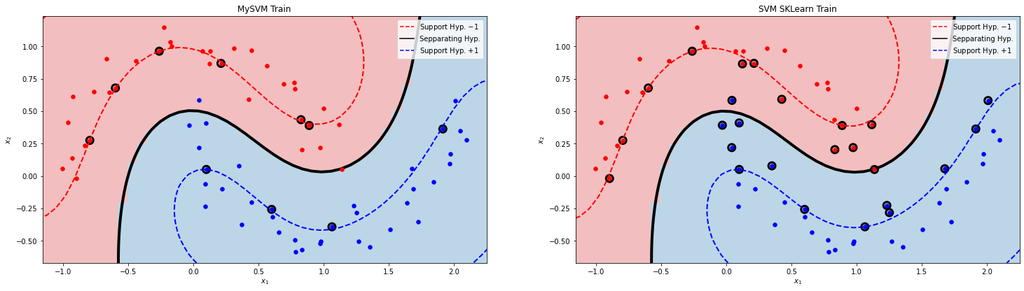

```python
fig, ax = plt.subplots(figsize=(25,6.5))

plt.subplot(121)
plot_svc(x_tr, y_tr, model_my)
plt.title("MySVM Train")

plt.subplot(122)
plot_svc(x_tr, y_tr, model_sk)
plt.title("SVM SKLearn Train")

plt.show()
```

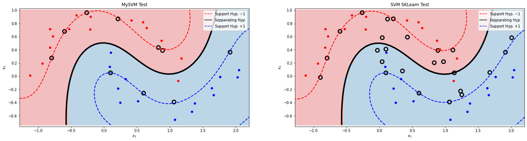

```python
fig, ax = plt.subplots(figsize=(25,6))

plt.subplot(121)
plot_svc(x_te, y_te, model_my)
plt.title("MySVM Test")

plt.subplot(122)
plot_svc(x_te, y_te, model_sk)
plt.title("SVM SKLearn Test")

plt.show()
```

### Predicciones

Se obtiene un 100% de similitud en las clasificaciones y un porcentaje de acierto aproximadamente igual a 96%.

```python
print((predictions_my==predictions_sk).all())
```

```
True
```

```python
we_c_my = np.where(y_te == predictions_my)[0]
wr_c_my = np.where(y_te != predictions_my)[0]
print("MySVC evaluation:")
print("Percentage of test success: {}".format(len(we_c_my)/len(y_te)))
print("Percentage of test failure: {}".format(len(wr_c_my)/len(y_te)))
```

```
MySVC evaluation:
Percentage of test success: 0.9666666666666667
Percentage of test failure: 0.03333333333333333
```

```python
we_c_sk = np.where(y_te == predictions_sk)[0]
wr_c_sk = np.where(y_te != predictions_sk)[0]
print("SKlearn SVC evaluation:")
print("Percentage of test success: {}".format(len(we_c_sk)/len(y_te)))
print("Percentage of test failure: {}".format(len(wr_c_sk)/len(y_te)))
```

```
SKlearn SVC evaluation:
Percentage of test success: 0.9666666666666667
Percentage of test failure: 0.03333333333333333
```

### Scores

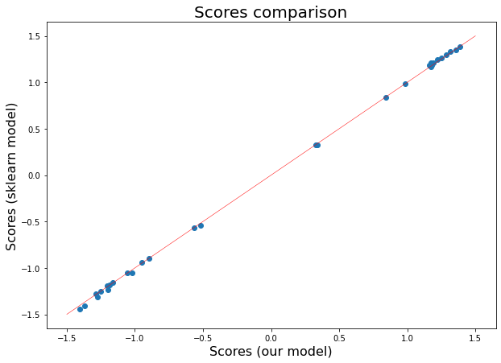

```
SME (test data): 0.00039
```

```python
x = np.linspace(-1.5, 1.5, 1000)
fig, ax = plt.subplots(figsize=(10, 7))
ax.plot(x, x, linewidth=0.5, linestyle='-', color='r')
ax.scatter(scores_my, scores_sk)
ax.set_title('Scores comparison', fontsize=20)
ax.set_xlabel('Scores (our model)', fontsize=16)
ax.set_ylabel('Scores (sklearn model)', fontsize=16)
plt.show()

# Squared mean error
print('SME (test data): {:.2}'.format(np.mean((scores_sk - scores_my) ** 2)))
```

## Understanding the SVM

* Considering the model created with the `MySVC` class: * Extract the list of support vectors, explaining the followed approach. * Extract the list of training points bad and well classified, explaining the followed approach. * Extract the list of training points that lie over the supporting hyperplanes. * Extract the list of training points located on the wrong side of the supporting hyperplanes, but that are well classified. * What are the conditions over the dual coefficients $\alpha_i$ that characterize the previous lists (if any)?

### Vectores de soporte y condiciones de los coeficientes duales $\alpha_i$

Los vectores de soporte tienen un papel fundamental en SVM ya que son los puntos que definen el margen máximo de separación del hiperplano que separa las clases. Estos vectores se seleccionan teniendo en cuenta los valores $\alpha$ que caen dentro del intervalo $(0, C)$.

Por tanto, aquellos puntos cuyo $\alpha$ esté en el rango $(0,C)$ son los vectores de soporte que se encuentran en el hiperplano de soporte. Aquellos puntos cuyo $\alpha$ sea igual a 0, se encuentran en su clase correspondiente fuera del hiperplano, lo que supone clasificaciones correctas. Finalmente, aquellos puntos para los que $\alpha=C$, se encuentran en el lado contrario de su clase correspondiente y se necesitará utilizar nuestro SVC para encontrar la clasificación y saber si fueron clasificados correctamente.

```
Indices k of Support vectors satisfying 0 < k < C =
 [ 1  2  6  9 15 19 35 37 39 57]

Alpha Support vectors =
 [0.73225384 0.28547352 0.3909361  0.24677378 0.07690949 0.61692409
 0.20459873 0.75210333 0.76184634 0.22145242]

Support vectors =
 [[-0.7952664   0.2746645 ]
 [ 0.59973944 -0.25787141]
 [ 0.09841814  0.05019174]
 [ 1.06252195 -0.39226767]
 [ 0.82483944  0.43424825]
 [ 0.88775478  0.38926482]
 [ 0.21104358  0.86864391]
 [-0.59960441  0.67856403]
 [-0.26285754  0.96232495]
 [ 1.91345677  0.3625312 ]]
```

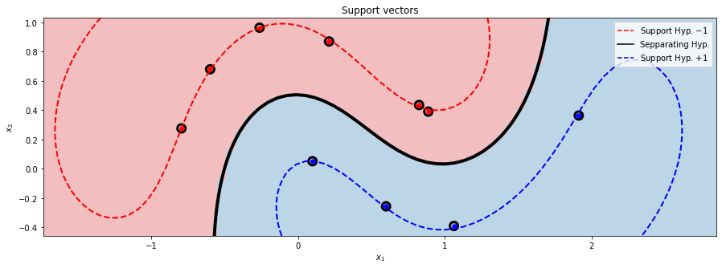

```python
print('Indices k of Support vectors satisfying 0 < k < C = \n', model_my.sv_cond_)
print('\nAlpha Support vectors = \n', model_my.a[model_my.sv_cond_])
print('\nSupport vectors = \n', model_my.support_vectors_)

plot_svc(x_tr[model_my.sv_cond_], y_tr[model_my.sv_cond_], model_my)
plt.title("Support vectors")
plt.show()
```

En este caso, vemos que los datos de entrenamiento seleccionados coinciden con los vectores de soporte (puntos con borde).

### Datos de entrenamiento mal y bien clasificados

Para encontrar los puntos de entrenamiento que consiguieron una buena clasificación se cuenta el número de puntos de entrenamiento que fueron clasificados según lo esperado y se divide entre el número total de puntos de entrenamiento. Se procede de la misma manera para los puntos mal clasificados.

```python
predictions_my_tr = model_my.predict(x_tr)

we_c_tr = np.where(y_tr == predictions_my_tr)[0]
print("Index list of training points well classified: {}".format(we_c_tr))
print("List of training points well classified: \n{}".format(x_tr[we_c_tr]))

wr_c_tr = np.where(y_tr != predictions_my_tr)[0]
print("\nIndex list of training points wrongly classified: {}".format(wr_c_tr))
print("List of training points wrongly classified: \n{}".format(x_tr[wr_c_tr]))

print("\nPercentage of training success: {}".format(len(we_c_tr)/len(y_tr)))
print("Percetage of training failure: {}".format(len(wr_c_tr)/len(y_tr)))
```

```
Index list of training points well classified: [ 0  1  2  3  4  5  6  7  8  9 10 11 12 13 14 15 16 17 18 19 20 21 22 23
 24 25 26 28 29 30 31 32 33 34 35 36 37 38 39 40 41 42 44 45 46 47 48 49
 50 51 52 53 54 55 56 57 58 59 60 61 62 63 64 65 66 67 68 69]
List of training points well classified:
[[ 1.68792426 -0.0981035 ]
 [-0.7952664   0.2746645 ]
 [ 0.59973944 -0.25787141]
 [ 0.9720389   0.21902698]
 [ 0.65462368 -0.43432386]
 [ 1.26610851 -0.50682361]
 [ 0.09841814  0.05019174]
 [ 0.56155158  0.85122387]
 [ 0.42448524  0.59130712]
 [ 1.06252195 -0.39226767]
 [-0.66625776  0.90611844]
 [-0.1785632   1.03583077]
 [ 2.04744488  0.35091483]
 [-0.9623992   0.41442543]
 [ 0.83169282 -0.56838816]
 [ 0.82483944  0.43424825]
 [ 0.44598685 -0.20238606]
 [-0.92514894  0.61051612]
 [ 0.06999164  0.96156857]
 [ 0.88775478  0.38926482]
 [ 1.23082636 -0.22735139]
 [ 1.63556454 -0.20700992]
 [-0.1701044   1.00266984]
 [ 0.96998002 -0.5188826 ]
 [ 1.115151    0.39583904]
 [ 1.96456314  0.09457656]
 [ 0.12278879  0.8649236 ]
 [-0.22651016  1.14840109]
 [ 0.21729751 -0.09860236]
 [-0.8367634   0.23609495]
 [ 1.67526518  0.05558455]
 [ 0.09103819 -0.06146458]
 [ 0.09012959 -0.23445768]
 [ 0.44663896  0.96634251]
 [ 0.21104358  0.86864391]
 [ 0.78550806 -0.58498755]
```

[output cut: 25 more lines]

```
 [ 1.35109293 -0.54851015]
 [-0.6473039   0.64284721]
 [-1.00391996  0.05940276]
 [-0.89675203 -0.01943427]
 [-0.76390856  0.65164261]
 [ 0.9782456  -0.50343744]
 [ 0.34875151  0.07811214]]

Index list of training points wrongly classified: [27 43]
List of training points wrongly classified:
[[1.13567114 0.04975262]
 [0.0423632  0.58312272]]

Percentage of training success: 0.9714285714285714
Percetage of training failure: 0.02857142857142857
```

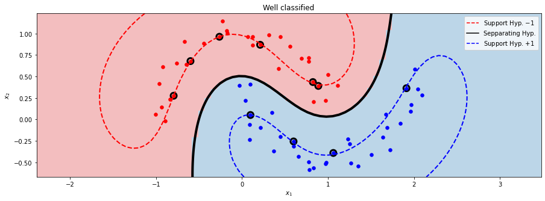

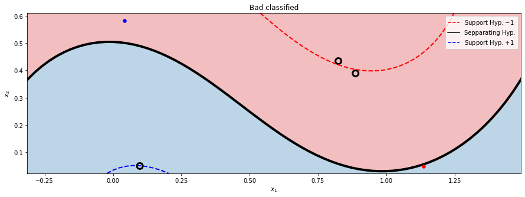

```python
plot_svc(x_tr[we_c_tr], y_tr[we_c_tr], model_my)
plt.title("Well classified")
plt.show()

plot_svc(x_tr[wr_c_tr], y_tr[wr_c_tr], model_my)
plt.title("Bad classified")
plt.show()
```

**Observación:** los puntos correspondientes a los vectores de soporte se representan como puntos con borde huecos por defecto. Sin embargo, los datos de entrenamiento solicitados son los que se muestran rellenos.

En este caso, hay exactamente dos puntos mal clasificados, uno de cada clase.

### Datos de entrenamiento cercanos a los hiperplanos de soporte

```
Index list of training points that lie over the supporting hyperplanes:[ 1  2  6  9 15 19 35 37 39 57]
List of training points that lie over the supporting hyperplanes:
[[-0.7952664   0.2746645 ]
 [ 0.59973944 -0.25787141]
 [ 0.09841814  0.05019174]
 [ 1.06252195 -0.39226767]
 [ 0.82483944  0.43424825]
 [ 0.88775478  0.38926482]
 [ 0.21104358  0.86864391]
 [-0.59960441  0.67856403]
 [-0.26285754  0.96232495]
 [ 1.91345677  0.3625312 ]]
```

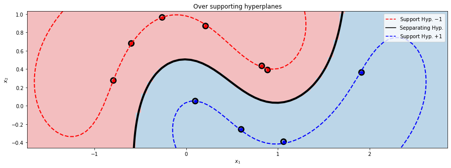

```python
scores_sv_c = np.where((model_my.a > 0) & (model_my.a < C))[0]
print('Index list of training points that lie over the supporting hyperplanes:{}'.format(scores_sv_c))
print('List of training points that lie over the supporting hyperplanes:\n{}'.format(x_tr[scores_sv_c]))
plot_svc(x_tr[scores_sv_c], y_tr[scores_sv_c], model_my)
plt.title("Over supporting hyperplanes")
plt.show()
```

Los puntos cercanos a los hiperplanos de soporte coinciden con los vectores de soporte. Variando la cota superior de $\alpha$, podemos seleccionar aquellos vectores de soporte que se encuentran más próximos a 0. En este caso se ha fijado una cota superior igual a 3e-1.

```
Index list of training points that lie over the supporting hyperplanes:[ 2  9 15 35 57]
List of training points that lie over the supporting hyperplanes:
[[ 0.59973944 -0.25787141]
 [ 1.06252195 -0.39226767]
 [ 0.82483944  0.43424825]
 [ 0.21104358  0.86864391]
 [ 1.91345677  0.3625312 ]]
```

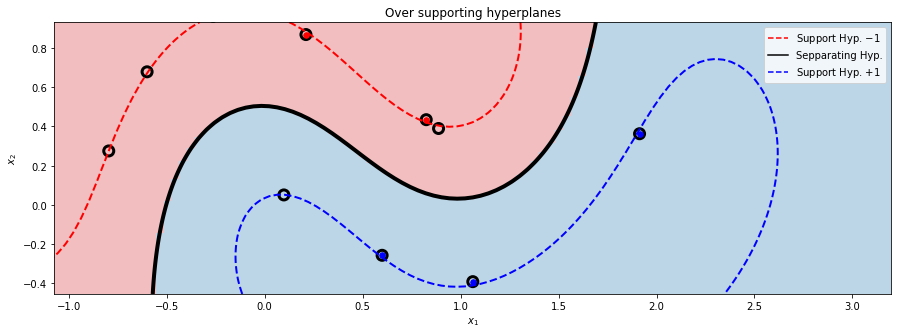

```python
scores_sv_c = np.where((model_my.a > 0) & (model_my.a < 3e-1))[0]
print('Index list of training points that lie over the supporting hyperplanes:{}'.format(scores_sv_c))
print('List of training points that lie over the supporting hyperplanes:\n{}'.format(x_tr[scores_sv_c]))
plot_svc(x_tr[scores_sv_c], y_tr[scores_sv_c], model_my)
plt.title("Over supporting hyperplanes")
plt.show()
```

### Datos de entrenamiento ubicados en el lado incorrecto de los hiperplanos de apoyo, pero bien clasificados

```
Index list of training points located on the wrong side of the supporting hyperplanes, but that are well classified: [ 3  8 20 24 26 31 44 50 52 53 55 62 66 69]
List of training points located on the wrong side of the supporting hyperplanes, but that are well classified:
[[ 0.9720389   0.21902698]
 [ 0.42448524  0.59130712]
 [ 1.23082636 -0.22735139]
 [ 1.115151    0.39583904]
 [ 0.12278879  0.8649236 ]
 [ 1.67526518  0.05558455]
 [-0.03147581  0.39140976]
 [ 1.25022826 -0.2826266 ]
 [ 2.00729148  0.58188871]
 [ 0.04062784  0.21890576]
 [ 0.83174596  0.20326404]
 [ 0.09781582  0.4090848 ]
 [-0.89675203 -0.01943427]
 [ 0.34875151  0.07811214]]
```

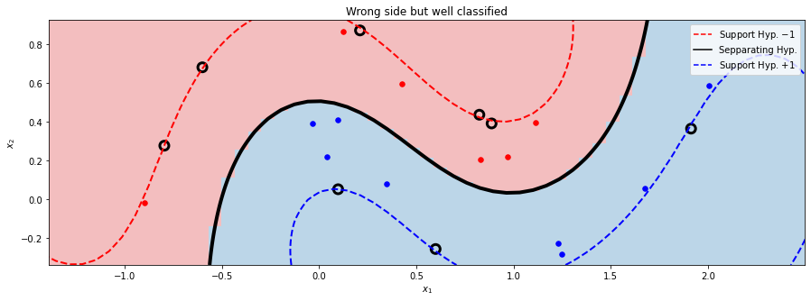

```python
wh = np.where(model_my.a == C)[0]
wh_i = wh[np.where(model_my.predict(x_tr[wh]) == y_tr[wh])[0]]
print('Index list of training points located on the wrong side of the supporting hyperplanes, but that are well classified: {}'.format(wh_i))
print('List of training points located on the wrong side of the supporting hyperplanes, but that are well classified:\n{}'.format(x_tr[wh_i]))
plot_svc(x_tr[wh_i], y_tr[wh_i], model_my)
plt.title("Wrong side but well classified")
plt.show()
```

Finalmente, se representan los datos de entrenamiento bien clasificados que se encuentran en el lado incorrecto de los hiperplanos de apoyo, es decir, aquellos datos para los que $\alpha=C$.